# EDA

```python
import numpy as np # linear algebra
import pandas as pd # data processing, CSV file I/O (e.g. pd.read_csv)
import os
from glob import glob
import matplotlib.pyplot as plt
import seaborn as sns
```

```python
## Below is some helper code to read all of your full image filepaths into a dataframe for easier manipulation

all_xray_df = pd.read_csv('/data/Data_Entry_2017.csv')
all_xray_df.sample(3)

data_sample = pd.read_csv('sample_labels.csv')
data_sample.sample(3)
```

|  | Image Index | Finding Labels | Follow-up # | Patient ID | Patient Age | Patient Gender | View Position | OriginalImageWidth | OriginalImageHeight | OriginalImagePixelSpacing_x | OriginalImagePixelSpacing_y |
| --- | --- | --- | --- | --- | --- | --- | --- | --- | --- | --- | --- |
| 588 | 00003043_000.png | No Finding | 0 | 3043 | 041Y | M | PA | 2500 | 2048 | 0.171 | 0.171 |
| 3443 | 00016977_000.png | No Finding | 0 | 16977 | 065Y | F | PA | 2992 | 2991 | 0.143 | 0.143 |
| 3893 | 00019176_079.png | Infiltration | 79 | 19176 | 066Y | F | AP | 3056 | 2544 | 0.139 | 0.139 |

EDA is open-ended, and it is up to you to decide how to look at different ways to slice and dice your data. A good starting point is to look at the requirements for the FDA documentation in the final part of this project to guide (some) of the analyses you do.

This EDA should also help to inform you of how pneumonia looks in the wild. E.g. what other types of diseases it's commonly found with, how often it is found, what ages it affects, etc.

Note that this NIH dataset was not specifically acquired for pneumonia. So, while this is a representation of 'pneumonia in the wild,' the prevalence of pneumonia may be different if you were to take only chest x-rays that were acquired in an ER setting with suspicion of pneumonia.

Also, **describe your findings and how will you set up the model training based on the findings.**

# Todo

- Perform gender , Age based analysis
- Create distributions of diseases and comorbidities in their dataset
- Draw conclusions about how they will need to set up their model training
- Use python’s imshow to visualize medical images during EDA
- Create distributions of intensity values of the pixel-level data within images and compare them both within and across diagnoses
- Use both of these methods of inspecting images to draw meaningful conclusions about what their model will train on

### 1. Perform gender , Age based analysis¶

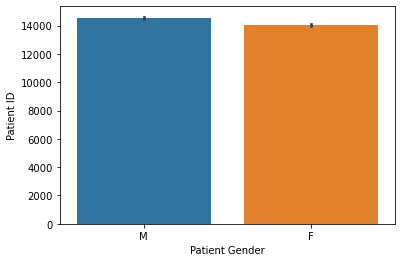

```python
def plot_gender_graph(df):
    gender_group =df.groupby('Patient Gender').count().reset_index()
    sns.barplot(x='Patient Gender',y='Patient ID',data=df)
plot_gender_graph(all_xray_df)
```

```
(0.0, 100.0)
```

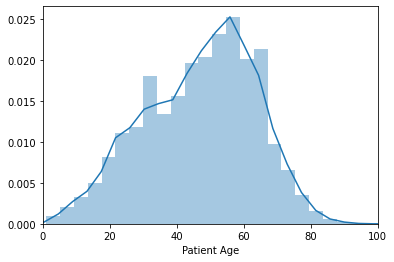

```python
sns.distplot(all_xray_df['Patient Age'], bins=100)
plt.xlim(0,100)
```

### 2. Create distributions of diseases and comorbidities in their dataset¶

```python
from itertools import chain

d = all_xray_df

all_labels = np.unique(list(chain(*d['Finding Labels'].map(lambda x: x.split('|')).tolist())))
all_labels = [x for x in all_labels if len(x)>0]
print('All Labels ({}): {}'.format(len(all_labels), all_labels))
for c_label in all_labels:
    if len(c_label)>1: # leave out empty labels
        d[c_label] = d['Finding Labels'].map(lambda finding: 1.0 if c_label in finding else 0)
```

```
All Labels (15): ['Atelectasis', 'Cardiomegaly', 'Consolidation', 'Edema', 'Effusion', 'Emphysema', 'Fibrosis', 'Hernia', 'Infiltration', 'Mass', 'No Finding', 'Nodule', 'Pleural_Thickening', 'Pneumonia', 'Pneumothorax']
```

```python
print("Unique disease combinations:", d['Finding Labels'].nunique())
```

```
Unique disease combinations: 836
```

```
[Text(0, 0.5, 'Number of Images with Label')]
```

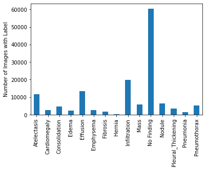

```python
ax = d[all_labels].sum().plot(kind='bar')
ax.set(ylabel = 'Number of Images with Label')
```

```python
d[d.Infiltration ==1]['Finding Labels'].value_counts()[:30]
```

```
Infiltration                                       9547
Effusion|Infiltration                              1603
Atelectasis|Infiltration                           1350
Infiltration|Nodule                                 829
Atelectasis|Effusion|Infiltration                   737
Consolidation|Infiltration                          441
Infiltration|Mass                                   420
Edema|Infiltration                                  392
Infiltration|Pneumothorax                           345
Infiltration|Pleural_Thickening                     210
Cardiomegaly|Infiltration                           200
Infiltration|Pneumonia                              199
Fibrosis|Infiltration                               185
Edema|Infiltration|Pneumonia                        137
Consolidation|Effusion|Infiltration                 134
Edema|Effusion|Infiltration                         127
Emphysema|Infiltration                              126
Cardiomegaly|Effusion|Infiltration                  120
Effusion|Infiltration|Nodule                        106
Atelectasis|Consolidation|Infiltration              104
Effusion|Infiltration|Mass                           99
Effusion|Infiltration|Pneumothorax                   88
Atelectasis|Consolidation|Effusion|Infiltration      81
Emphysema|Infiltration|Pneumothorax                  72
Effusion|Infiltration|Pleural_Thickening             71
Atelectasis|Infiltration|Pneumothorax                71
Infiltration|Mass|Nodule                             67
Atelectasis|Infiltration|Mass                        67
Atelectasis|Infiltration|Nodule                      57
Atelectasis|Cardiomegaly|Effusion|Infiltration       54
Name: Finding Labels, dtype: int64
```

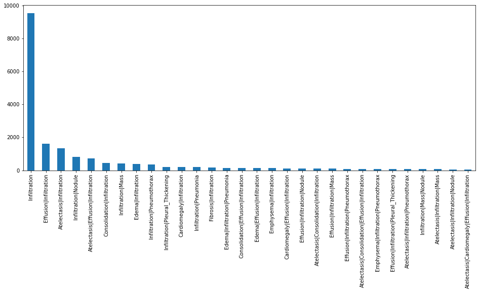

```python
##Since there are many combinations of potential findings, I'm going to look at the 30 most common co-occurrences:
plt.figure(figsize=(16,6))
d[d.Infiltration==1]['Finding Labels'].value_counts()[:30].plot(kind='bar')
```

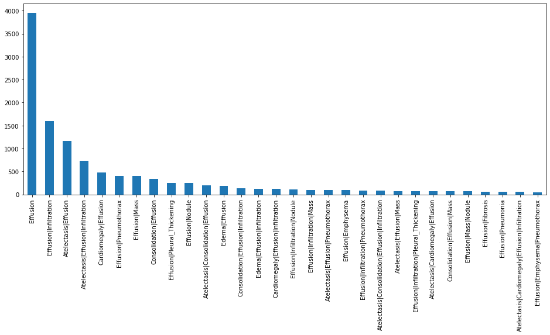

```python
##Since there are many combinations of potential findings, I'm going to look at the 30 most common co-occurrences:
plt.figure(figsize=(16,6))
d[d.Effusion==1]['Finding Labels'].value_counts()[0:30].plot(kind='bar')
```

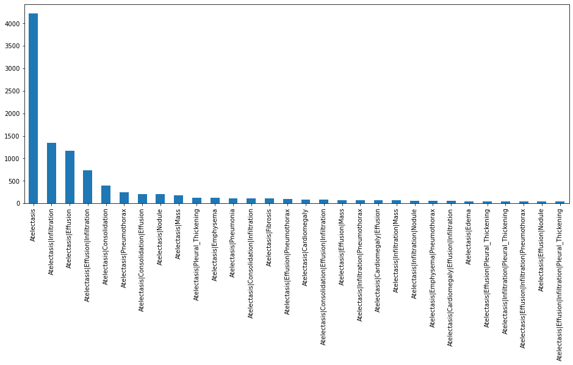

```python
##Since there are many combinations of potential findings, I'm going to look at the 30 most common co-occurrences:
plt.figure(figsize=(16,6))
d[d.Atelectasis==1]['Finding Labels'].value_counts()[0:30].plot(kind='bar')
```

### Other diseases that co-occur with pneumonia

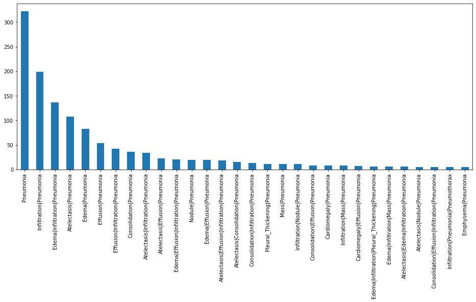

```python
##Since there are many combinations of potential findings, I'm going to look at the 30 most common co-occurrences:
plt.figure(figsize=(16,6))
d[d.Pneumonia==1]['Finding Labels'].value_counts()[0:30].plot(kind='bar')
```

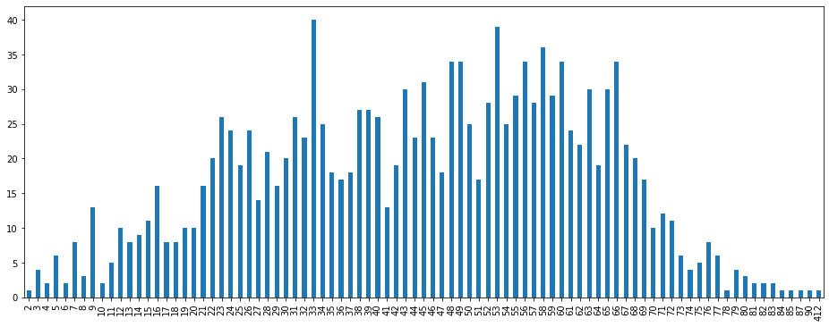

```python
plt.figure(figsize=(16,6))
d[d.Pneumonia==1]['Patient Age'].value_counts().sort_index().plot.bar()
```

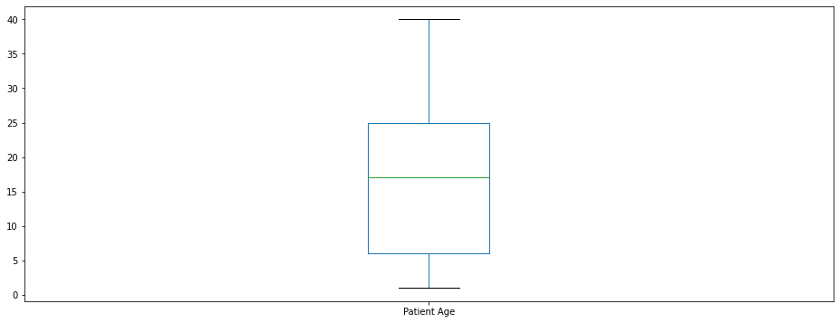

```python
plt.figure(figsize=(16,6))
d[d.Pneumonia==1]['Patient Age'].value_counts().sort_index().plot.box()
```

### 4. Students use python’s imshow to visualize medical images during EDA

The student can visualize relevant properties of pixel-level data

Students use python’s imshow to visualize medical images during EDA

Students create distributions of intensity values of the pixel-level data within images and compare them both within and across diagnoses

Students use both of these methods of inspecting images to draw meaningful conclusions about what their model will train on

```python
##Import any other packages you may need here
%matplotlib notebook
import pydicom
import skimage
```

```python
mydicoms = glob("*.dcm")

test_dicom, test_dicom_img = [], []
for i in range(len(mydicoms)):
    test_dicom.append(pydicom.dcmread(mydicoms[i]))
    test_dicom_img.append(test_dicom[i].pixel_array)
    print("Study Description of ", mydicoms[i], "/ test_dicom_img[",i,"] : ", test_dicom[i].StudyDescription )
```

```
Study Description of  test2.dcm / test_dicom_img[ 0 ] :  Cardiomegaly
Study Description of  test5.dcm / test_dicom_img[ 1 ] :  No Finding
Study Description of  test1.dcm / test_dicom_img[ 2 ] :  No Finding
Study Description of  test4.dcm / test_dicom_img[ 3 ] :  No Finding
Study Description of  test6.dcm / test_dicom_img[ 4 ] :  No Finding
Study Description of  test3.dcm / test_dicom_img[ 5 ] :  Effusion
```

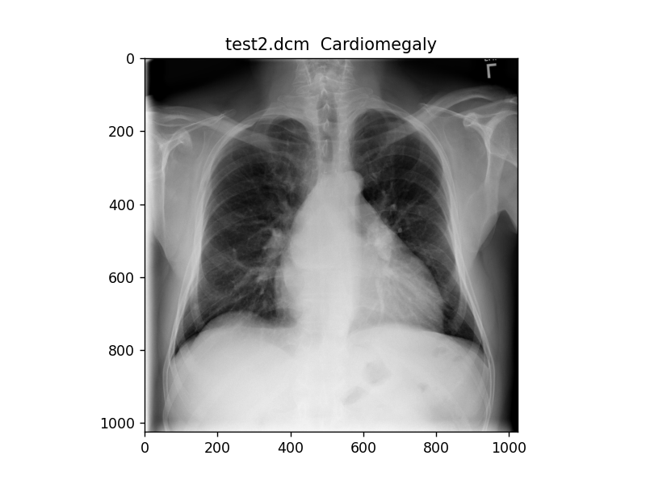

```python
plt.imshow(test_dicom_img[0], cmap='gray')
plt.title(mydicoms[0]+ "  " +test_dicom[0].StudyDescription)
```

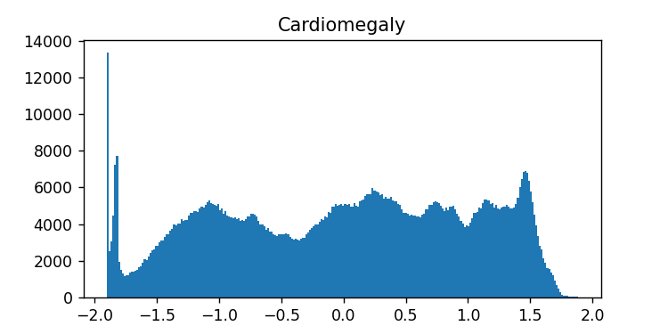

```python
mean, std = np.mean(test_dicom_img[0]), np.std(test_dicom_img[0])
new_img = (test_dicom_img[0] - mean)/std
plt.figure(figsize=(6, 3))
plt.hist(new_img.ravel(), bins = 256)
plt.title("Cardiomegaly")
```

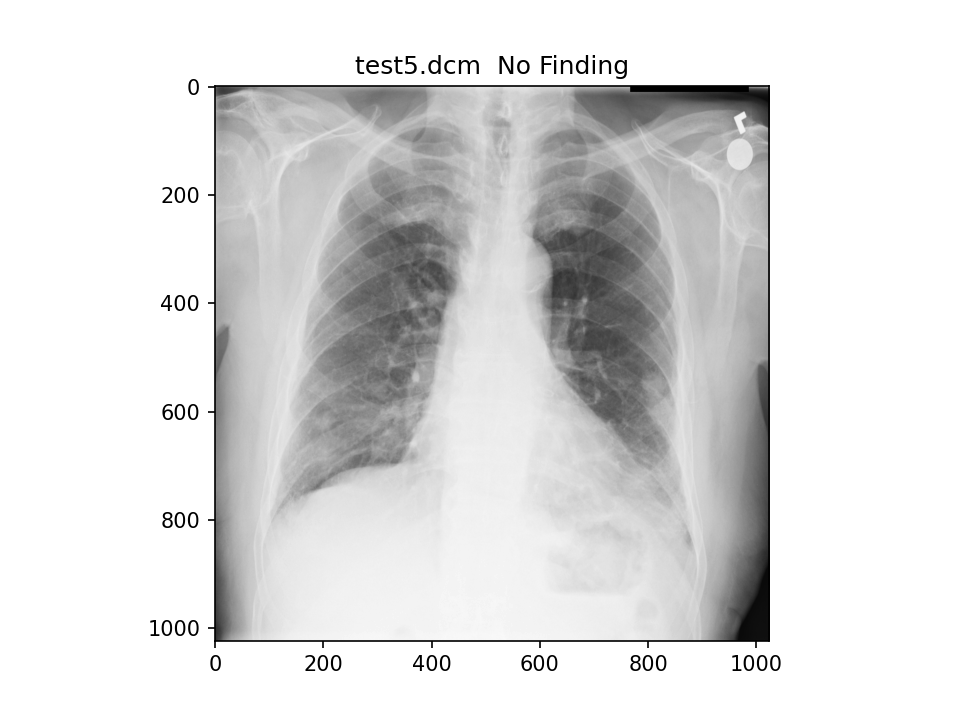

```python
plt.imshow(test_dicom_img[1], cmap='gray')
plt.title(mydicoms[1]+ "  " +test_dicom[1].StudyDescription)
```

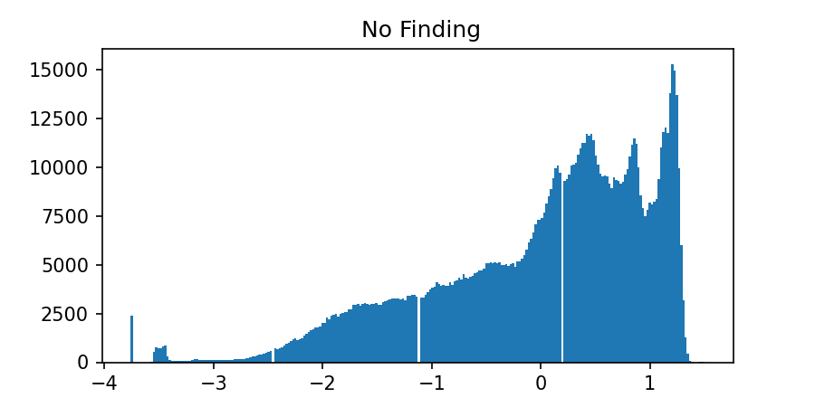

```python
mean, std = np.mean(test_dicom_img[1]), np.std(test_dicom_img[1])
new_img = (test_dicom_img[1] - mean)/std
plt.figure(figsize=(6, 3))
plt.hist(new_img.ravel(), bins = 256)
plt.title(" No Finding")
```

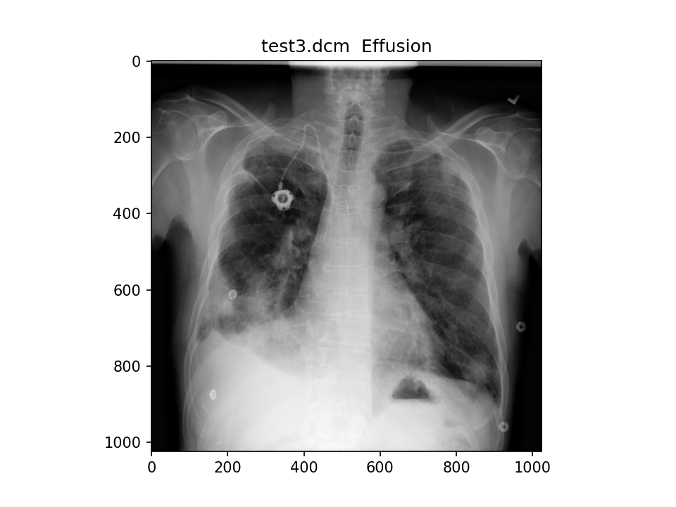

```python
plt.imshow(test_dicom_img[5], cmap='gray')
plt.title(mydicoms[5]+ "  " +test_dicom[5].StudyDescription)
```

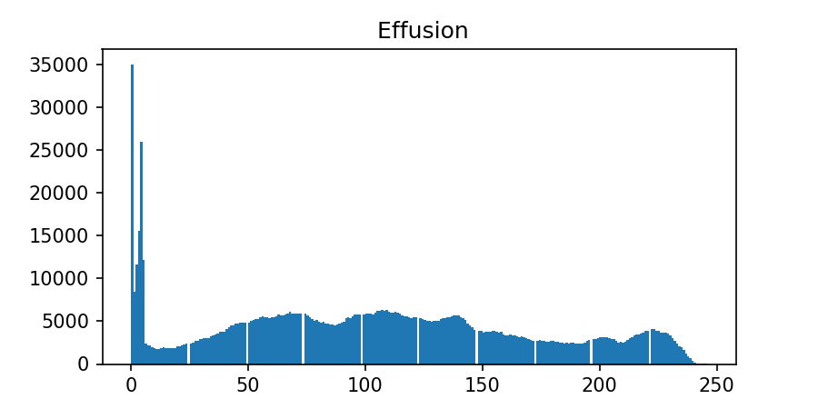

```python
mean, std = np.mean(test_dicom_img[5]), np.std(test_dicom_img[5])
new_img = (test_dicom_img[5] - mean)/std
plt.figure(figsize=(6, 3))
plt.hist(test_dicom_img[5].ravel(), bins = 256)
plt.title(" Effusion")
```